# Contribution of Africa's sub-regions to Maize and Wheat production from 2001 to 2020

## Investigation Overview

In this investigation I wanted to look at how the different sub-regions in Africa fared in terms of maize and wheat and maize production to determine which regions would need the most support.

The agricultural Gross Production Index (GPI) is one of the methods used to determine amount of food production. This Index is prepared by the Food and Agriculture Organization of the United Nations (FAO). The FAO indices of agricultural production show the relative level of the aggregate volume of agricultural production for each year in comparison with the base period 2014-2016.

## Dataset Overview

The data consisted of all countries and regions with different food categories. This data was coupled with production indices from 1961 to 2020. We extracted data on world and Africa prodcution indices for maize and wheat from 2001 to 2020. We then further focused on the main sub-regions in Africa (Eastern Africa, Middle Africa, Northern Africa, Southern Africa and Western Africa) to clarify certain trends.

# World and Africa GPI for Maize

Maize and Wheat production in Africa saw a wide range of recorded production compared to world data from 2001 to 2020. This could be caused either by wide differences in production from different parts of the continent oro significant fluctuations in production or a combination of both

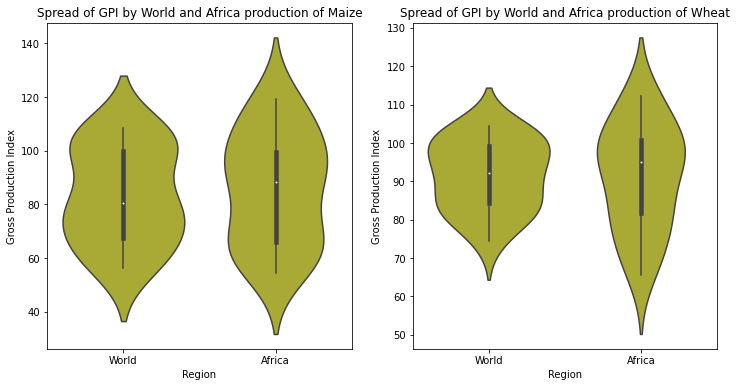

# Trend of World and Africa GPI for Wheat

The trends for both Maize and Wheat show that the wide range of GPI for Africa was caused by te relatively larger fluctuations in production of each cereal compared to global production. Fluctuations were more severe in Africa's Wheat production. Acccording to data from the FAO, there was an average 130% increase in Maize production by Africa from 2001 to 2020 while total world production saw an 83% increase within the same period. Africa's Wheat production saw a lower growth at around 37% within the same time period with world's growt even lower at 25%.

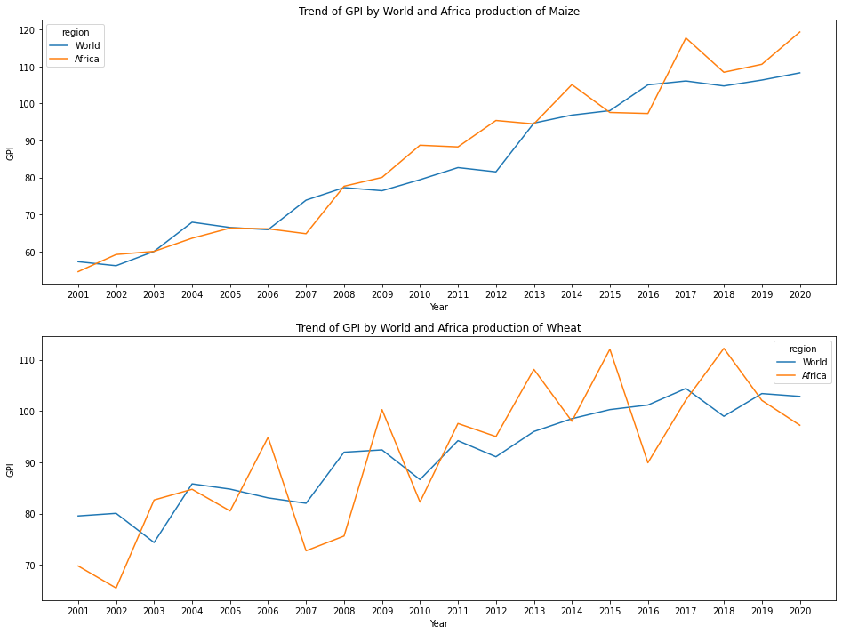

# Africa GPI for Maize by sub-Region

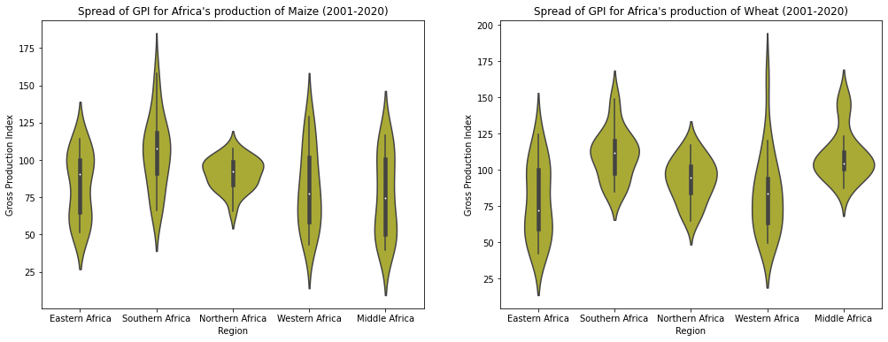

# Trend of Africa GPI for Maize and Wheat by sub-Regions

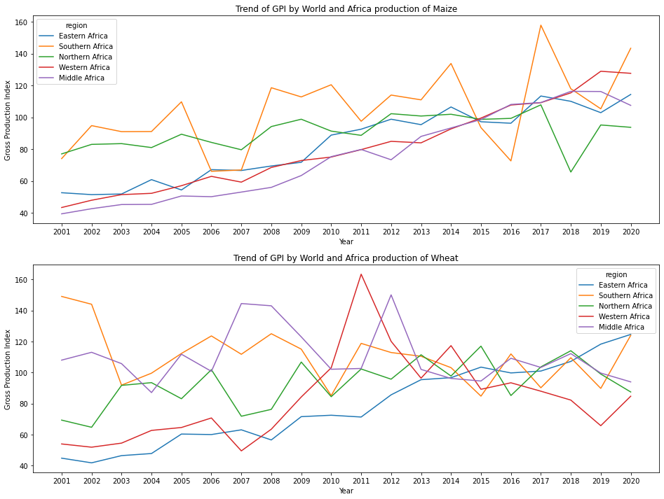

# Percentage Maize Production in Africa by Region at Intervals

Southern Africa maintained its position as the major producing region in Africa for Maize for most part of the 20 years under study. The biggest gainer was West Africa who moved from a percentage share of 15% in 2001 to 22.2% by 2020. Nothern Africa dropped the most percentage share from 27% to 16.2%.

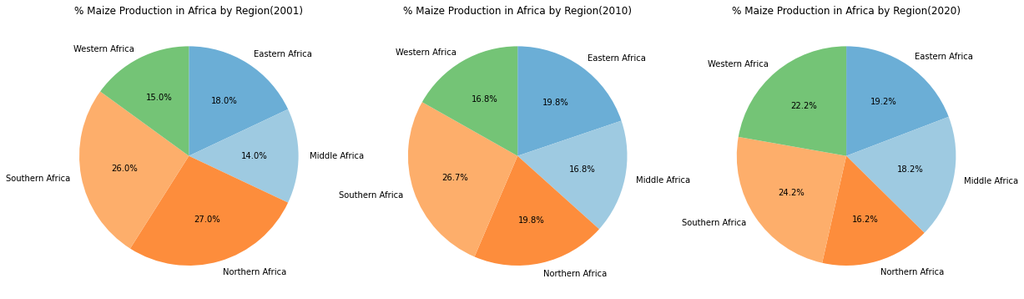

# Percentage Wheat Production in Africa by Region at Intervals

Eastern Africa saw it's percentage share of Africa's total Wheat production more than double across the 20 years moving from 11% to 24.2%. The plots show Western Africa's rise and subsequent fall in percentage contribution.

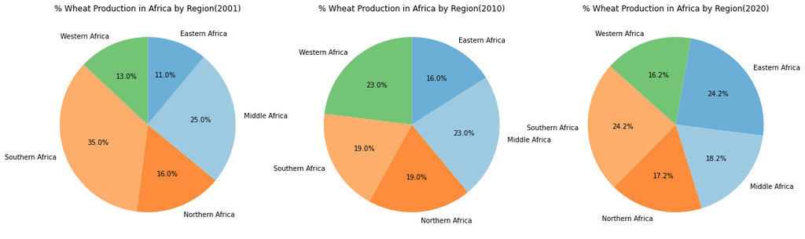